# replication_data

```python
# ============================================================
# 0. Imports & Configuration
# ============================================================
# This notebook replicates the main tables and figures from:
#   Reisenbichler, Reutterer & Schweidel (2025)
#   "Applying Large Language Models to Sponsored Search Advertising"
#   Marketing Science (forthcoming)
#
# Original analyses were in R; this notebook reproduces them
# in Python, using the same .RData files shipped with the
# replication package.
# ============================================================

# --- Standard data-science stack ---
import pandas as pd                          # DataFrames
import numpy as np                           # Numerical operations
import matplotlib.pyplot as plt              # Plotting / visualisation

# --- Reading R data files ---
import pyreadr                               # Read .RData into pandas

# --- Statistical tests ---
from scipy import stats                      # Chi-squared, Kruskal-Wallis, Mann-Whitney U …
from scipy.stats import chi2_contingency     # Contingency-table chi-squared test
from statsmodels.stats.proportion import proportions_ztest  # Two-sample proportion z-test

import warnings
warnings.filterwarnings('ignore')            # Suppress routine warnings for cleaner output

# --- Data path (adjust if the folder is somewhere else on your machine) ---
DATA_PATH = "/Users/weiqiuhong/Desktop/DOTE 6635/Replication/mksc.2023.0611/main paper tables and figures/"


# ---- Helper functions ----

def load_rdata(filename):
    """Load an .RData file and return a dict {object_name: DataFrame}."""
    return pyreadr.read_r(DATA_PATH + filename)


def display_summary(title, data):
    """Print a formatted section header, then display a DataFrame or text."""
    print(f"\n{'='*60}")
    print(f"  {title}")
    print(f"{'='*60}")
    if isinstance(data, pd.DataFrame):
        display(data)
    else:
        print(data)


print("Libraries loaded successfully.")
print(f"Data path: {DATA_PATH}")
```

```
Libraries loaded successfully.
Data path: /Users/weiqiuhong/Desktop/DOTE 6635/Replication/mksc.2023.0611/main paper tables and figures/
```

## Table 3: Campaign Performance — IT&SaaS Industry

Replicates **Table 3** from the paper for the IT&SaaS industry.  
Metrics: Number of Ads, Impressions, Clicks, Conversions, Costs, CPC (Median), Quality Score.  
Statistical tests: Chi-squared test, Kruskal-Wallis test.

```python
# =============================================
# Table 3 — IT&SaaS: Load Data
# =============================================
# Load the .RData file which contains two objects:
#   IT_tab3 : ad-level campaign metrics (impressions, clicks, cost, CPC …)
#   IT_QS   : ad-level Quality Score data
rdata = load_rdata("Table 3 IT.RData")
print("Objects loaded:", list(rdata.keys()))

IT_tab3 = rdata['IT_tab3']   # Campaign performance data
IT_QS   = rdata['IT_QS']     # Quality Score data

# Quick inspection of columns and size
print("\n--- IT_tab3 columns ---")
print(IT_tab3.columns.tolist())
print(f"Shape: {IT_tab3.shape}")

print("\n--- IT_QS columns ---")
print(IT_QS.columns.tolist())
print(f"Shape: {IT_QS.shape}")
```

```
Objects loaded: ['IT_QS', 'IT_tab3']

--- IT_tab3 columns ---
['Anzeigentitel.1', 'Anzeigentitel.2', 'Anzeigentitel.3', 'Textzeile.1', 'Textzeile.2', 'Impr.', 'Interaktionen', 'Interaktionsrate', 'Durchschn..Kosten', 'Kosten', 'CTR', 'Klicks', 'Durchschn..CPC', 'Impr...oberste.Pos...', 'Impr...obere.Pos...', 'Experimental.group']
Shape: (162, 16)

--- IT_QS columns ---
['Experimental.group', 'revised.Cos_Ad_LP', 'revised.Cos_Ad_top10', 'revised.keyw_integr_Main_keyw', 'revised.keyw_integr_ad.top10', 'revised.keyw_integr_ad.LP', 'revised.Cos_top10', 'revised.l_top10', 'revised.Cos_LP', 'revised.l_LP', 'revised.QS']
Shape: (162, 11)
```

```python
# =============================================
# Table 3 IT — Campaign Performance Metrics
# =============================================
# For each experimental group (Human Novice / GPT-3 / PPLM),
# compute aggregate campaign KPIs and run goodness-of-fit or
# non-parametric tests to check whether groups differ.

# 1) Number of ads created per experimental group
No_ads = IT_tab3.groupby('Experimental.group')['Impr.'].count().reset_index()
No_ads.columns = ['Category', 'No_ads']
display_summary("Number of Ads per Group (IT)", No_ads)

# 2) Total impressions per group + chi-squared goodness-of-fit
#    (H0: impressions are uniformly distributed across groups)
No_impr = IT_tab3.groupby('Experimental.group')['Impr.'].sum().reset_index()
No_impr.columns = ['Category', 'Impressions']
display_summary("Impressions per Group (IT)", No_impr)
chi2_impr = stats.chisquare(No_impr['Impressions'])
print(f"Chi-squared test: statistic={chi2_impr.statistic:.4f}, p-value={chi2_impr.pvalue:.4f}")

# 3) Total clicks per group + chi-squared
No_clicks = IT_tab3.groupby('Experimental.group')['Klicks'].sum().reset_index()
No_clicks.columns = ['Category', 'Clicks']
display_summary("Clicks per Group (IT)", No_clicks)
chi2_clicks = stats.chisquare(No_clicks['Clicks'])
print(f"Chi-squared test: statistic={chi2_clicks.statistic:.4f}, p-value={chi2_clicks.pvalue:.4f}")

# 4) Estimated conversions = clicks × group-specific conversion rate
#    Conversion rates come from Table A19 in the Web Appendix
conv_rates = [0.0197, 0.02, 0.02]
No_Conversions = np.round(No_clicks['Clicks'].values * conv_rates).astype(int)
display_summary("Conversions per Group (IT)",
                pd.DataFrame({'Category': No_clicks['Category'], 'Conversions': No_Conversions}))
chi2_conv = stats.chisquare(No_Conversions)
print(f"Chi-squared test: statistic={chi2_conv.statistic:.4f}, p-value={chi2_conv.pvalue:.4f}")

# 5) Total advertising costs per group + chi-squared
Costs = IT_tab3.groupby('Experimental.group')['Kosten'].sum().reset_index()
Costs.columns = ['Category', 'Total_Cost']
display_summary("Costs per Group (IT)", Costs)
chi2_costs = stats.chisquare(Costs['Total_Cost'])
print(f"Chi-squared test: statistic={chi2_costs.statistic:.4f}, p-value={chi2_costs.pvalue:.4f}")

# 6) Cost per Click (CPC) — descriptive statistics (median, IQR, range)
CPC = IT_tab3.groupby('Experimental.group')['Durchschn..CPC'].agg(
    Median='median', IQR=lambda x: stats.iqr(x, nan_policy='omit'),
    Min='min', Max='max'
).reset_index()
CPC.columns = ['Category', 'Median', 'IQR', 'Min', 'Max']
display_summary("CPC Statistics per Group (IT)", CPC)

# Kruskal-Wallis H-test (non-parametric ANOVA) for CPC across groups
groups_cpc = [g['Durchschn..CPC'].dropna().values for _, g in IT_tab3.groupby('Experimental.group')]
kw_cpc = stats.kruskal(*groups_cpc)
print(f"Kruskal-Wallis test (CPC): statistic={kw_cpc.statistic:.4f}, p-value={kw_cpc.pvalue:.4f}")
```

```
============================================================
  Number of Ads per Group (IT)
============================================================
```

|  | Category | No_ads |
| --- | --- | --- |
| 0 | Human novices | 76 |
| 1 | PPLM 04 best QS | 76 |
| 2 | Real experts | 10 |

```
============================================================
  Impressions per Group (IT)
============================================================
```

|  | Category | Impressions |
| --- | --- | --- |
| 0 | Human novices | 12031.0 |
| 1 | PPLM 04 best QS | 34590.0 |
| 2 | Real experts | 1255.0 |

```
Chi-squared test: statistic=36265.6212, p-value=0.0000

============================================================
  Clicks per Group (IT)
============================================================
```

|  | Category | Clicks |
| --- | --- | --- |
| 0 | Human novices | 530.0 |
| 1 | PPLM 04 best QS | 1507.0 |
| 2 | Real experts | 7.0 |

```
Chi-squared test: statistic=1701.5939, p-value=0.0000

============================================================
  Conversions per Group (IT)
============================================================
```

|  | Category | Conversions |
| --- | --- | --- |
| 0 | Human novices | 10 |
| 1 | PPLM 04 best QS | 30 |
| 2 | Real experts | 0 |

```
Chi-squared test: statistic=35.0000, p-value=0.0000

============================================================
  Costs per Group (IT)
============================================================
```

|  | Category | Total_Cost |
| --- | --- | --- |
| 0 | Human novices | 136.87 |
| 1 | PPLM 04 best QS | 462.73 |
| 2 | Real experts | 2.67 |

```
Chi-squared test: statistic=557.6396, p-value=0.0000

============================================================
  CPC Statistics per Group (IT)
============================================================
```

|  | Category | Median | IQR | Min | Max |
| --- | --- | --- | --- | --- | --- |
| 0 | Human novices | 0.260 | 0.075 | 0.06 | 3.28 |
| 1 | PPLM 04 best QS | 0.285 | 0.080 | 0.03 | 4.52 |
| 2 | Real experts | 0.380 | 0.000 | 0.38 | 0.38 |

```
Kruskal-Wallis test (CPC): statistic=7.0875, p-value=0.0289
```

```python
# =============================================
# Table 3 IT — Quality Score (QS)
# =============================================
# Google's Quality Score (revised) summarises ad relevance,
# landing-page experience and expected CTR on a 1–10 scale.
# We report median / IQR / range by group, then test with
# Kruskal-Wallis (appropriate because QS is ordinal).

QS_np = IT_QS.groupby('Experimental.group')['revised.QS'].agg(
    Median='median', IQR=lambda x: stats.iqr(x, nan_policy='omit'),
    Min='min', Max='max'
).reset_index()
QS_np.columns = ['Category', 'Median', 'IQR', 'Min', 'Max']
display_summary("Quality Score per Group (IT)", QS_np)

# Kruskal-Wallis H-test for Quality Score
groups_qs = [g['revised.QS'].dropna().values for _, g in IT_QS.groupby('Experimental.group')]
kw_qs = stats.kruskal(*groups_qs)
print(f"Kruskal-Wallis test (Quality Score): statistic={kw_qs.statistic:.4f}, p-value={kw_qs.pvalue:.4f}")
```

```
============================================================
  Quality Score per Group (IT)
============================================================
```

|  | Category | Median | IQR | Min | Max |
| --- | --- | --- | --- | --- | --- |
| 0 | Human novices | 0.305397 | 0.143948 | 0.042265 | 0.486550 |
| 1 | PPLM 04 best QS | 0.438604 | 0.053134 | 0.274197 | 0.532343 |
| 2 | Real experts | 0.288986 | 0.077605 | 0.219615 | 0.401231 |

```
Kruskal-Wallis test (Quality Score): statistic=81.1308, p-value=0.0000
```

## Table 3: Campaign Performance — Education Industry

Replicates **Table 3** from the paper for the Education industry.

```python
# =============================================
# Table 3 — Education: Load Data
# =============================================
# Same structure as the IT dataset but for the Education industry.
#   edu    : ad-level campaign metrics
#   edu_QS : ad-level Quality Score data
rdata_edu = load_rdata("Table 3 education.RData")
print("Objects loaded:", list(rdata_edu.keys()))

for k, v in rdata_edu.items():
    print(f"\n--- {k} columns ---")
    print(v.columns.tolist())
    print(f"Shape: {v.shape}")
```

```
Objects loaded: ['edu_QS', 'edu']

--- edu_QS columns ---
['Exp_group', 'Headline.1', 'Headline.2', 'Headline.3', 'Text.1', 'Text.2', 'QS.revised.text']
Shape: (279, 7)

--- edu columns ---
['Klicks', 'Impr.', 'CTR', 'Durchschn..CPC', 'Kosten', 'Impr...oberste.Pos...', 'Impr...obere.Pos...', 'Exp_group']
Shape: (181, 8)
```

```python
# =============================================
# Table 3 Education — Campaign Performance & QS
# =============================================
# Mirrors the IT analysis above but for the Education industry.
# Note: the group column is named 'Exp_group' (not 'Experimental.group').

edu    = rdata_edu['edu']       # Campaign metrics
edu_QS = rdata_edu['edu_QS']   # Quality Score data

# 1) Number of ads
No_ads = edu.groupby('Exp_group')['Impr.'].count().reset_index()
No_ads.columns = ['Category', 'No_ads']
display_summary("Number of Ads per Group (Education)", No_ads)

# 2) Impressions + chi-squared
No_impr = edu.groupby('Exp_group')['Impr.'].sum().reset_index()
No_impr.columns = ['Category', 'Impressions']
display_summary("Impressions per Group (Education)", No_impr)
chi2_impr = stats.chisquare(No_impr['Impressions'])
print(f"Chi-squared test: statistic={chi2_impr.statistic:.4f}, p-value={chi2_impr.pvalue:.4f}")

# 3) Clicks + chi-squared
No_clicks = edu.groupby('Exp_group')['Klicks'].sum().reset_index()
No_clicks.columns = ['Category', 'Clicks']
display_summary("Clicks per Group (Education)", No_clicks)
chi2_clicks = stats.chisquare(No_clicks['Clicks'])
print(f"Chi-squared test: statistic={chi2_clicks.statistic:.4f}, p-value={chi2_clicks.pvalue:.4f}")

# 4) Estimated conversions (conversion rates from Table A19 Web Appendix)
conv_rates_edu = [0.0765, 0.0765, 0.08]
No_Conversions = np.round(No_clicks['Clicks'].values * conv_rates_edu).astype(int)
display_summary("Conversions per Group (Education)",
                pd.DataFrame({'Category': No_clicks['Category'], 'Conversions': No_Conversions}))
chi2_conv = stats.chisquare(No_Conversions)
print(f"Chi-squared test: statistic={chi2_conv.statistic:.4f}, p-value={chi2_conv.pvalue:.4f}")

# 5) Total costs + chi-squared
Costs = edu.groupby('Exp_group')['Kosten'].sum().reset_index()
Costs.columns = ['Category', 'Total_Cost']
display_summary("Costs per Group (Education)", Costs)
chi2_costs = stats.chisquare(Costs['Total_Cost'])
print(f"Chi-squared test: statistic={chi2_costs.statistic:.4f}, p-value={chi2_costs.pvalue:.4f}")

# 6) CPC descriptives + Kruskal-Wallis
CPC = edu.groupby('Exp_group')['Durchschn..CPC'].agg(
    Median='median', IQR=lambda x: stats.iqr(x, nan_policy='omit'),
    Min='min', Max='max'
).reset_index()
CPC.columns = ['Category', 'Median', 'IQR', 'Min', 'Max']
display_summary("CPC Statistics per Group (Education)", CPC)

groups_cpc = [g['Durchschn..CPC'].dropna().values for _, g in edu.groupby('Exp_group')]
kw_cpc = stats.kruskal(*groups_cpc)
print(f"Kruskal-Wallis test (CPC): statistic={kw_cpc.statistic:.4f}, p-value={kw_cpc.pvalue:.4f}")

# 7) Quality Score descriptives + Kruskal-Wallis
QS_np = edu_QS.groupby('Exp_group')['QS.revised.text'].agg(
    Median='median', IQR=lambda x: stats.iqr(x, nan_policy='omit'),
    Min='min', Max='max'
).reset_index()
QS_np.columns = ['Category', 'Median', 'IQR', 'Min', 'Max']
display_summary("Quality Score per Group (Education)", QS_np)

groups_qs = [g['QS.revised.text'].dropna().values for _, g in edu_QS.groupby('Exp_group')]
kw_qs = stats.kruskal(*groups_qs)
print(f"Kruskal-Wallis test (Quality Score): statistic={kw_qs.statistic:.4f}, p-value={kw_qs.pvalue:.4f}")
```

```
============================================================
  Number of Ads per Group (Education)
============================================================
```

|  | Category | No_ads |
| --- | --- | --- |
| 0 | Human novice | 82 |
| 1 | PPLM | 82 |
| 2 | Real experts | 17 |

```
============================================================
  Impressions per Group (Education)
============================================================
```

|  | Category | Impressions |
| --- | --- | --- |
| 0 | Human novice | 17374.0 |
| 1 | PPLM | 21252.0 |
| 2 | Real experts | 9741.0 |

```
Chi-squared test: statistic=4255.0643, p-value=0.0000

============================================================
  Clicks per Group (Education)
============================================================
```

|  | Category | Clicks |
| --- | --- | --- |
| 0 | Human novice | 1802.0 |
| 1 | PPLM | 2002.0 |
| 2 | Real experts | 1330.0 |

```
Chi-squared test: statistic=139.1445, p-value=0.0000

============================================================
  Conversions per Group (Education)
============================================================
```

|  | Category | Conversions |
| --- | --- | --- |
| 0 | Human novice | 138 |
| 1 | PPLM | 153 |
| 2 | Real experts | 106 |

```
Chi-squared test: statistic=8.7103, p-value=0.0128

============================================================
  Costs per Group (Education)
============================================================
```

|  | Category | Total_Cost |
| --- | --- | --- |
| 0 | Human novice | 845.17 |
| 1 | PPLM | 951.94 |
| 2 | Real experts | 657.03 |

```
Chi-squared test: statistic=54.5072, p-value=0.0000

============================================================
  CPC Statistics per Group (Education)
============================================================
```

|  | Category | Median | IQR | Min | Max |
| --- | --- | --- | --- | --- | --- |
| 0 | Human novice | 0.49 | 0.035 | 0.26 | 0.63 |
| 1 | PPLM | 0.50 | 0.030 | 0.32 | 0.67 |
| 2 | Real experts | 0.56 | 0.040 | 0.40 | 0.82 |

```
Kruskal-Wallis test (CPC): statistic=17.9859, p-value=0.0001

============================================================
  Quality Score per Group (Education)
============================================================
```

|  | Category | Median | IQR | Min | Max |
| --- | --- | --- | --- | --- | --- |
| 0 | Human novice | 0.320107 | 0.085216 | 0.049337 | 0.424918 |
| 1 | PPLM17_revised | 0.427604 | 0.062905 | 0.239695 | 0.528591 |
| 2 | Real Experts | 0.241249 | 0.108089 | 0.149983 | 0.373185 |

```
Kruskal-Wallis test (Quality Score): statistic=169.8259, p-value=0.0000
```

## Table 4: Campaign Performance with LLM-Generated Ads — IT&SaaS Industry

Replicates **Table 4** from the paper for the IT&SaaS industry (ads generated by different LLMs).  
Metrics: Number of Ads, Impressions, Clicks, Conversions, CPC, Quality Score.  
Statistical tests: Chi-squared test, Kruskal-Wallis test.

```python
# =============================================
# Table 4 — IT&SaaS: Load Data
# =============================================
# Table 4 compares ads generated by different LLMs.
#   IT_dat : ad-level campaign data (with Avg..CPC instead of Durchschn..CPC)
#   QS     : Quality Score per model
rdata_t4it = load_rdata("Table 4 IT.RData")
print("Objects loaded:", list(rdata_t4it.keys()))

for k, v in rdata_t4it.items():
    print(f"\n--- {k} columns ---")
    print(v.columns.tolist())
    print(f"Shape: {v.shape}")
```

```
Objects loaded: ['QS', 'IT_dat']

--- QS columns ---
['model_ID', 'keywordstocrawl', 'Generated_text', 'Competition..index.', 'top10_cleaned', 'LP_cleaned', 'keyword', 'top10_keywords', 'LP_keywords', 'PPLM_QS_texts_conc', 'Cos_Ad_LP', 'Cos_Ad_top10', 'keyw_integr_Main_keyw', 'keyw_integr_ad.top10', 'keyw_integr_ad.LP', 'Cos_top10', 'l_top10', 'Cos_LP…
Shape: (114, 24)

--- IT_dat columns ---
['Headline.1.x', 'Headline.2.x', 'Headline.3.x', 'Description.1', 'Description.2', 'Clicks', 'Impr.', 'CTR', 'Avg..CPC', 'Cost', 'Experimental.group', 'Keywords']
Shape: (114, 12)
```

```python
# =============================================
# Table 4 IT — Campaign Performance & QS
# =============================================
# Analysis mirrors Table 3 but groups are defined by which LLM
# wrote the ad copy (e.g., GPT-3, ChatGPT …).
# Conversion rate is uniform at 2 % across all groups here.

IT_dat   = rdata_t4it['IT_dat']   # Campaign data
QS_t4it  = rdata_t4it['QS']      # Quality Score data

# 1) Number of ads
No_ads = IT_dat.groupby('Experimental.group')['Impr.'].count().reset_index()
No_ads.columns = ['Category', 'No_ads']
display_summary("Number of Ads per Group (Table 4 IT)", No_ads)

# 2) Impressions + chi-squared
No_impr = IT_dat.groupby('Experimental.group')['Impr.'].sum().reset_index()
No_impr.columns = ['Category', 'Impressions']
display_summary("Impressions per Group (Table 4 IT)", No_impr)
chi2_impr = stats.chisquare(No_impr['Impressions'])
print(f"Chi-squared test: statistic={chi2_impr.statistic:.4f}, p-value={chi2_impr.pvalue:.4f}")

# 3) Clicks + chi-squared
No_clicks = IT_dat.groupby('Experimental.group')['Clicks'].sum().reset_index()
No_clicks.columns = ['Category', 'Clicks']
display_summary("Clicks per Group (Table 4 IT)", No_clicks)
chi2_clicks = stats.chisquare(No_clicks['Clicks'])
print(f"Chi-squared test: statistic={chi2_clicks.statistic:.4f}, p-value={chi2_clicks.pvalue:.4f}")

# 4) Estimated conversions (uniform 2 % rate for all groups)
No_Conversions = np.round(No_clicks['Clicks'].values * 0.02).astype(int)
display_summary("Conversions per Group (Table 4 IT)",
                pd.DataFrame({'Category': No_clicks['Category'], 'Conversions': No_Conversions}))
chi2_conv = stats.chisquare(No_Conversions)
print(f"Chi-squared test: statistic={chi2_conv.statistic:.4f}, p-value={chi2_conv.pvalue:.4f}")

# 5) CPC descriptives + Kruskal-Wallis
#    Note: column name is 'Avg..CPC' (English export), not 'Durchschn..CPC'
CPC = IT_dat.groupby('Experimental.group')['Avg..CPC'].agg(
    Median='median', IQR=lambda x: stats.iqr(x, nan_policy='omit'),
    Min='min', Max='max'
).reset_index()
CPC.columns = ['Category', 'Median', 'IQR', 'Min', 'Max']
display_summary("CPC Statistics per Group (Table 4 IT)", CPC)

groups_cpc = [g['Avg..CPC'].dropna().values for _, g in IT_dat.groupby('Experimental.group')]
kw_cpc = stats.kruskal(*groups_cpc)
print(f"Kruskal-Wallis test (CPC): statistic={kw_cpc.statistic:.4f}, p-value={kw_cpc.pvalue:.4f}")

# 6) Quality Score per LLM model + Kruskal-Wallis
QSad = QS_t4it.groupby('model_ID')['QS'].agg(
    Median='median', SD='std', Min='min', Max='max'
).reset_index()
QSad.columns = ['Category', 'Median', 'SD', 'Min', 'Max']
display_summary("Quality Score per Model (Table 4 IT)", QSad)

groups_qs = [g['QS'].dropna().values for _, g in QS_t4it.groupby('model_ID')]
kw_qs = stats.kruskal(*groups_qs)
print(f"Kruskal-Wallis test (Quality Score): statistic={kw_qs.statistic:.4f}, p-value={kw_qs.pvalue:.4f}")
```

```
============================================================
  Number of Ads per Group (Table 4 IT)
============================================================
```

|  | Category | No_ads |
| --- | --- | --- |
| 0 | ChatGPT_finetuned | 19 |
| 1 | GPT-4 base | 19 |
| 2 | GPT-4 best | 19 |
| 3 | GoogleAds | 19 |
| 4 | Human novices | 19 |
| 5 | PPLM 04 best QS | 19 |

```
============================================================
  Impressions per Group (Table 4 IT)
============================================================
```

|  | Category | Impressions |
| --- | --- | --- |
| 0 | ChatGPT_finetuned | 4006.0 |
| 1 | GPT-4 base | 824.0 |
| 2 | GPT-4 best | 1159.0 |
| 3 | GoogleAds | 5973.0 |
| 4 | Human novices | 4611.0 |
| 5 | PPLM 04 best QS | 14226.0 |

```
Chi-squared test: statistic=23239.2647, p-value=0.0000

============================================================
  Clicks per Group (Table 4 IT)
============================================================
```

|  | Category | Clicks |
| --- | --- | --- |
| 0 | ChatGPT_finetuned | 224.0 |
| 1 | GPT-4 base | 53.0 |
| 2 | GPT-4 best | 83.0 |
| 3 | GoogleAds | 323.0 |
| 4 | Human novices | 210.0 |
| 5 | PPLM 04 best QS | 782.0 |

```
Chi-squared test: statistic=1261.6937, p-value=0.0000

============================================================
  Conversions per Group (Table 4 IT)
============================================================
```

|  | Category | Conversions |
| --- | --- | --- |
| 0 | ChatGPT_finetuned | 4 |
| 1 | GPT-4 base | 1 |
| 2 | GPT-4 best | 2 |
| 3 | GoogleAds | 6 |
| 4 | Human novices | 4 |
| 5 | PPLM 04 best QS | 16 |

```
Chi-squared test: statistic=26.8182, p-value=0.0001

============================================================
  CPC Statistics per Group (Table 4 IT)
============================================================
```

|  | Category | Median | IQR | Min | Max |
| --- | --- | --- | --- | --- | --- |
| 0 | ChatGPT_finetuned | 0.37 | 0.035 | 0.0 | 0.43 |
| 1 | GPT-4 base | 0.33 | 0.370 | 0.0 | 0.42 |
| 2 | GPT-4 best | 0.33 | 0.250 | 0.0 | 0.56 |
| 3 | GoogleAds | 0.36 | 0.380 | 0.0 | 0.43 |
| 4 | Human novices | 0.34 | 0.235 | 0.0 | 0.46 |
| 5 | PPLM 04 best QS | 0.37 | 0.035 | 0.3 | 0.40 |

```
Kruskal-Wallis test (CPC): statistic=6.8519, p-value=0.2319

============================================================
  Quality Score per Model (Table 4 IT)
============================================================
```

|  | Category | Median | SD | Min | Max |
| --- | --- | --- | --- | --- | --- |
| 0 | ChatGPT_finetuned | 0.386468 | 0.036834 | 0.319910 | 0.453413 |
| 1 | GPT-4 base | 0.289844 | 0.078638 | 0.123252 | 0.413359 |
| 2 | GPT-4 best | 0.403921 | 0.073196 | 0.203529 | 0.489983 |
| 3 | GoogleAds | 0.365113 | 0.079090 | 0.163849 | 0.438901 |
| 4 | Human novices | 0.304797 | 0.119366 | 0.107461 | 0.480982 |
| 5 | PPLM 04 best QS | 0.467248 | 0.042277 | 0.349411 | 0.531290 |

```
Kruskal-Wallis test (Quality Score): statistic=49.6869, p-value=0.0000
```

## Table 4: Campaign Performance with LLM-Generated Ads — Education Industry

Replicates **Table 4** from the paper for the Education industry.

```python
# =============================================
# Table 4 — Education: Load Data
# =============================================
# Same comparison of LLM-generated ads, but for the Education industry.
#   edu_tab4 : campaign data (includes a real 'Conversions' column tracked by the university)
#   QS       : Quality Score per model
rdata_t4edu = load_rdata("Table 4 education.RData")
print("Objects loaded:", list(rdata_t4edu.keys()))

for k, v in rdata_t4edu.items():
    print(f"\n--- {k} columns ---")
    print(v.columns.tolist())
    print(f"Shape: {v.shape}")
```

```
Objects loaded: ['QS', 'edu_tab4']

--- QS columns ---
['model_ID', 'keywordstocrawl', 'Generated_text', 'Competition..index.', 'top10_cleaned', 'LP_cleaned', 'keyword', 'top10_keywords', 'LP_keywords', 'PPLM_QS_texts_conc', 'Cos_Ad_LP', 'Cos_Ad_top10', 'keyw_integr_Main_keyw', 'keyw_integr_ad.top10', 'keyw_integr_ad.LP', 'Cos_top10', 'l_top10', 'Cos_LP…
Shape: (114, 24)

--- edu_tab4 columns ---
['Experimental.group', 'Subgroup', 'Keywords', 'Headline.1.x', 'Headline.2.x', 'Headline.3.x', 'Text.1', 'Text.2', 'Landing.page', 'matcher', 'Final.URL', 'Headline.1.y', 'Headline.2.y', 'Headline.3.y', 'Description.1', 'Description.2', 'Clicks', 'Impr.', 'CTR', 'Cost', 'Conv..rate', 'Conversions', …
Shape: (114, 23)
```

```python
# =============================================
# Table 4 Education — Campaign Performance & QS
# =============================================
# Unlike the IT dataset, the Education data has *actual* tracked
# conversions (column 'Conversions') rather than estimated ones.
# CPC is computed manually as Cost / Clicks.

edu_tab4 = rdata_t4edu['edu_tab4']   # Campaign data
QS_t4edu = rdata_t4edu['QS']         # Quality Score data

# 1) Number of ads
No_ads = edu_tab4.groupby('Experimental.group')['Impr.'].count().reset_index()
No_ads.columns = ['Category', 'No_ads']
display_summary("Number of Ads per Group (Table 4 Education)", No_ads)

# 2) Impressions + chi-squared
No_impr = edu_tab4.groupby('Experimental.group')['Impr.'].sum().reset_index()
No_impr.columns = ['Category', 'Impressions']
display_summary("Impressions per Group (Table 4 Education)", No_impr)
chi2_impr = stats.chisquare(No_impr['Impressions'])
print(f"Chi-squared test: statistic={chi2_impr.statistic:.4f}, p-value={chi2_impr.pvalue:.4f}")

# 3) Clicks + chi-squared
No_clicks = edu_tab4.groupby('Experimental.group')['Clicks'].sum().reset_index()
No_clicks.columns = ['Category', 'Clicks']
display_summary("Clicks per Group (Table 4 Education)", No_clicks)
chi2_clicks = stats.chisquare(No_clicks['Clicks'])
print(f"Chi-squared test: statistic={chi2_clicks.statistic:.4f}, p-value={chi2_clicks.pvalue:.4f}")

# 4) Real conversions (tracked by WU — Vienna University of Economics)
Real_Conversions = edu_tab4.groupby('Experimental.group')['Conversions'].sum().reset_index()
Real_Conversions.columns = ['Category', 'Conversions']
display_summary("Real Conversions per Group (Table 4 Education)", Real_Conversions)
chi2_conv = stats.chisquare(Real_Conversions['Conversions'])
print(f"Chi-squared test: statistic={chi2_conv.statistic:.4f}, p-value={chi2_conv.pvalue:.4f}")

# 5) CPC = Cost / Clicks (computed ad-level, then summarised)
edu_tab4['CPC'] = edu_tab4['Cost'] / edu_tab4['Clicks']
CPC = edu_tab4.groupby('Experimental.group')['CPC'].agg(
    Median='median', IQR=lambda x: stats.iqr(x, nan_policy='omit'),
    Min='min', Max='max'
).reset_index()
CPC.columns = ['Category', 'Median', 'IQR', 'Min', 'Max']
display_summary("CPC Statistics per Group (Table 4 Education)", CPC)

groups_cpc = [g['CPC'].dropna().values for _, g in edu_tab4.groupby('Experimental.group')]
kw_cpc = stats.kruskal(*groups_cpc)
print(f"Kruskal-Wallis test (CPC): statistic={kw_cpc.statistic:.4f}, p-value={kw_cpc.pvalue:.4f}")

# 6) Quality Score per model + Kruskal-Wallis
QSad = QS_t4edu.groupby('model_ID')['QS'].agg(
    Median='median', IQR=lambda x: stats.iqr(x, nan_policy='omit'),
    Min='min', Max='max'
).reset_index()
QSad.columns = ['Category', 'Median', 'IQR', 'Min', 'Max']
display_summary("Quality Score per Model (Table 4 Education)", QSad)

groups_qs = [g['QS'].dropna().values for _, g in QS_t4edu.groupby('model_ID')]
kw_qs = stats.kruskal(*groups_qs)
print(f"Kruskal-Wallis test (Quality Score): statistic={kw_qs.statistic:.4f}, p-value={kw_qs.pvalue:.4f}")
```

```
============================================================
  Number of Ads per Group (Table 4 Education)
============================================================
```

|  | Category | No_ads |
| --- | --- | --- |
| 0 | ChatGPT best | 18 |
| 1 | GPT4-base | 19 |
| 2 | GPT4-best | 19 |
| 3 | Google ads | 19 |
| 4 | Human_kw | 19 |
| 5 | PPLM | 19 |

```
============================================================
  Impressions per Group (Table 4 Education)
============================================================
```

|  | Category | Impressions |
| --- | --- | --- |
| 0 | ChatGPT best | 9256.0 |
| 1 | GPT4-base | 261.0 |
| 2 | GPT4-best | 17244.0 |
| 3 | Google ads | 7890.0 |
| 4 | Human_kw | 18882.0 |
| 5 | PPLM | 24645.0 |

```
Chi-squared test: statistic=29979.4286, p-value=0.0000

============================================================
  Clicks per Group (Table 4 Education)
============================================================
```

|  | Category | Clicks |
| --- | --- | --- |
| 0 | ChatGPT best | 1063.0 |
| 1 | GPT4-base | 41.0 |
| 2 | GPT4-best | 2192.0 |
| 3 | Google ads | 1255.0 |
| 4 | Human_kw | 3200.0 |
| 5 | PPLM | 3598.0 |

```
Chi-squared test: statistic=4879.9944, p-value=0.0000

============================================================
  Real Conversions per Group (Table 4 Education)
============================================================
```

|  | Category | Conversions |
| --- | --- | --- |
| 0 | ChatGPT best | 8.0 |
| 1 | GPT4-base | 3.0 |
| 2 | GPT4-best | 7.0 |
| 3 | Google ads | 19.0 |
| 4 | Human_kw | 52.0 |
| 5 | PPLM | 76.0 |

```
Chi-squared test: statistic=160.9273, p-value=0.0000

============================================================
  CPC Statistics per Group (Table 4 Education)
============================================================
```

|  | Category | Median | IQR | Min | Max |
| --- | --- | --- | --- | --- | --- |
| 0 | ChatGPT best | 0.115071 | 0.041999 | 0.070000 | 0.211579 |
| 1 | GPT4-base | 0.093000 | 0.033000 | 0.042857 | 0.164286 |
| 2 | GPT4-best | 0.108182 | 0.013395 | 0.093830 | 0.183333 |
| 3 | Google ads | 0.112839 | 0.010141 | 0.090000 | 0.390000 |
| 4 | Human_kw | 0.103822 | 0.010408 | 0.065484 | 0.125918 |
| 5 | PPLM | 0.110471 | 0.020729 | 0.083403 | 0.142680 |

```
Kruskal-Wallis test (CPC): statistic=10.4016, p-value=0.0646

============================================================
  Quality Score per Model (Table 4 Education)
============================================================
```

|  | Category | Median | IQR | Min | Max |
| --- | --- | --- | --- | --- | --- |
| 0 | ChatGPT best | 0.272932 | 0.107746 | 0.171694 | 0.414668 |
| 1 | GPT4-base | 0.281232 | 0.113119 | 0.143071 | 0.315473 |
| 2 | GPT4-best | 0.327279 | 0.136221 | 0.161762 | 0.455630 |
| 3 | Google ads | 0.329101 | 0.072629 | 0.217065 | 0.379273 |
| 4 | Human_kw | 0.352495 | 0.063007 | 0.216993 | 0.417916 |
| 5 | PPLM | 0.420692 | 0.036368 | 0.331429 | 0.486615 |

```
Kruskal-Wallis test (Quality Score): statistic=48.2607, p-value=0.0000
```

## Table 5: SEA Performance Under Varying Campaign Setups — IT&SaaS

Replicates **Table 5** from the paper.  
Compares performance across **unconstrained budget** and **constrained budget** conditions, with three campaign setups each:

1. Original setup
2. Original setup (PPLM ads disabled)
3. Isolated campaigns

```python
# =============================================
# Table 5 — IT&SaaS: Load Data
# =============================================
# The .RData file contains *six* DataFrames for a 3 × 2 design:
#   3 campaign setups  ×  2 budget conditions (high / low).
# We iterate over the keys to inspect each one.
rdata_t5 = load_rdata("Table 5 IT.RData")
print("Objects loaded:", list(rdata_t5.keys()))

for k, v in rdata_t5.items():
    print(f"\n--- {k} ---")
    print(f"  Columns: {v.columns.tolist()}")
    print(f"  Shape: {v.shape}")
```

```
Objects loaded: ['isolated_campaigns', 'orig_setup', 'original_setup_but_PPLM_ads_disabled', 'original_setup_but_PPLM_ads_disabled_lowbudget', 'orig_setup_lowbudget', 'isolated_campaigns_lowbudget']

--- isolated_campaigns ---
  Columns: ['Campaign status', 'Campaign', 'Budget type', 'Currency code', 'Optimisation score', 'Campaign type', 'Impr.', 'Interactions', 'Interaction rate', 'Bid strategy type', 'Viewable CTR', 'Avg. viewable CPM', 'Viewable impr.', 'Clicks', 'Conv. rate', 'Conversions', 'Cost / conv.']
  Shape: (2, 17)

--- orig_setup ---
  Columns: ['Ad status', 'Final URL', 'Headline 1.x', 'Headline 2.x', 'Headline 3.x', 'Description 1', 'Description 2', 'Ad group', 'Clicks', 'Impr.', 'CTR', 'Experimental group', 'Keywords']
  Shape: (38, 13)

--- original_setup_but_PPLM_ads_disabled ---
  Columns: ['Ad status', 'Final URL', 'Headline 1.x', 'Headline 2.x', 'Headline 3.x', 'Description 1', 'Description 2', 'Ad group', 'Clicks', 'Impr.', 'CTR', 'Experimental group', 'Keywords']
  Shape: (38, 13)

--- original_setup_but_PPLM_ads_disabled_lowbudget ---
  Columns: ['Ad status', 'Final URL', 'Headline 1.x', 'Headline 2.x', 'Headline 3.x', 'Description 1', 'Description 2', 'Ad group', 'Clicks', 'Impr.', 'CTR', 'Experimental group', 'Keywords']
  Shape: (38, 13)

--- orig_setup_lowbudget ---
  Columns: ['Ad status', 'Final URL', 'Headline 1.x', 'Headline 2.x', 'Headline 3.x', 'Description 1', 'Description 2', 'Ad group', 'Clicks', 'Impr.', 'CTR', 'Experimental group', 'Keywords']
  Shape: (38, 13)

--- isolated_campaigns_lowbudget ---
  Columns: ['Campaign status', 'Campaign', 'Budget type', 'Currency code', 'Optimisation score', 'Campaign type', 'Impr.', 'Interactions', 'Interaction rate', 'Bid strategy type', 'Viewable CTR', 'Avg. viewable CPM', 'Viewable impr.', 'Clicks', 'Conv. rate', 'Conversions', 'Cost / conv.']
  Shape: (2, 17)
```

```python
# =============================================
# Table 5 — Helper Function & Data Exploration
# =============================================

def analyze_table5_setup(df, group_col, label):
    """
    Summarise a single Table 5 campaign setup:
      - number of ads
      - total impressions  (+ chi-squared goodness-of-fit)
      - total clicks       (+ chi-squared goodness-of-fit)
    Returns (impressions_df, clicks_df) for further use.
    """
    print(f"\n{'='*60}")
    print(f"  {label}")
    print(f"{'='*60}")

    No_ads = df.groupby(group_col)['Impr.'].count().reset_index()
    No_ads.columns = ['Category', 'No_ads']
    print("\nNumber of Ads:")
    display(No_ads)

    No_impr = df.groupby(group_col)['Impr.'].sum().reset_index()
    No_impr.columns = ['Category', 'Impressions']
    print("\nImpressions:")
    display(No_impr)
    chi2 = stats.chisquare(No_impr['Impressions'])
    print(f"  Chi-squared test: statistic={chi2.statistic:.4f}, p-value={chi2.pvalue:.4f}")

    No_clicks = df.groupby(group_col)['Clicks'].sum().reset_index()
    No_clicks.columns = ['Category', 'Clicks']
    print("\nClicks:")
    display(No_clicks)
    chi2 = stats.chisquare(No_clicks['Clicks'])
    print(f"  Chi-squared test: statistic={chi2.statistic:.4f}, p-value={chi2.pvalue:.4f}")

    return No_impr, No_clicks


# Helper to auto-detect the grouping column in each DataFrame
def find_group_col(df):
    """Return the first column whose name contains 'xperimental' or 'Campaign'."""
    for c in df.columns:
        if 'xperimental' in c or 'Campaign' in c:
            return c
    return None


# Quick overview of available datasets and their group columns
t5_keys = list(rdata_t5.keys())
print("Available datasets:", t5_keys)
for k in t5_keys:
    df = rdata_t5[k]
    group_cols = [c for c in df.columns if 'xperimental' in c or 'Campaign' in c or 'group' in c.lower()]
    print(f"\n{k}: group columns = {group_cols}, shape = {df.shape}")
```

```
Available datasets: ['isolated_campaigns', 'orig_setup', 'original_setup_but_PPLM_ads_disabled', 'original_setup_but_PPLM_ads_disabled_lowbudget', 'orig_setup_lowbudget', 'isolated_campaigns_lowbudget']

isolated_campaigns: group columns = ['Campaign status', 'Campaign', 'Campaign type'], shape = (2, 17)

orig_setup: group columns = ['Ad group', 'Experimental group'], shape = (38, 13)

original_setup_but_PPLM_ads_disabled: group columns = ['Ad group', 'Experimental group'], shape = (38, 13)

original_setup_but_PPLM_ads_disabled_lowbudget: group columns = ['Ad group', 'Experimental group'], shape = (38, 13)

orig_setup_lowbudget: group columns = ['Ad group', 'Experimental group'], shape = (38, 13)

isolated_campaigns_lowbudget: group columns = ['Campaign status', 'Campaign', 'Campaign type'], shape = (2, 17)
```

```python
# =============================================
# Table 5 — Full Analysis (6 Setups)
# =============================================
# We iterate over the six datasets in a structured order:
#   Unconstrained budget → orig_setup, PPLM disabled, isolated campaigns
#   Constrained  budget → same three setups with "_lowbudget" suffix
# For PPLM-disabled setups, additional comparison chi-sq tests are run
# against the original setup numbers (hard-coded from the paper).

print("=" * 70)
print("  UNCONSTRAINED BUDGET")
print("=" * 70)

# 1. Original setup (unconstrained)
for key in rdata_t5:
    if 'orig_setup' == key or key == 'orig_setup':
        df = rdata_t5[key]
        gcol = find_group_col(df)
        if gcol:
            analyze_table5_setup(df, gcol, "Original Setup (Unconstrained Budget)")
        break

# 2. Original setup but PPLM ads disabled (unconstrained)
for key in rdata_t5:
    if 'PPLM' in key and 'lowbudget' not in key:
        df = rdata_t5[key]
        gcol = find_group_col(df)
        if gcol:
            analyze_table5_setup(df, gcol, "Original Setup, PPLM Ads Disabled (Unconstrained)")
            # Additional chi-sq against orig setup
            print("\n  Comparison chi-sq tests against original setup:")
            print(f"  Impressions: chi2={stats.chisquare([1756+218, 1190]).statistic:.4f}, p={stats.chisquare([1756+218, 1190]).pvalue:.4f}")
            print(f"  Clicks: chi2={stats.chisquare([45+12, 23]).statistic:.4f}, p={stats.chisquare([45+12, 23]).pvalue:.4f}")
        break

# 3. Isolated campaigns (unconstrained)
for key in rdata_t5:
    if 'isolated' in key and 'lowbudget' not in key:
        df = rdata_t5[key]
        gcol = find_group_col(df)
        if gcol:
            # Isolated campaigns only have impressions and clicks
            print(f"\n{'='*60}")
            print(f"  Isolated Campaigns (Unconstrained Budget)")
            print(f"{'='*60}")
            No_impr = df.groupby(gcol)['Impr.'].sum().reset_index()
            No_impr.columns = ['Category', 'Impressions']
            print("\nImpressions:")
            display(No_impr)
            chi2 = stats.chisquare(No_impr['Impressions'])
            print(f"  Chi-squared test: statistic={chi2.statistic:.4f}, p-value={chi2.pvalue:.4f}")

            No_clicks = df.groupby(gcol)['Clicks'].sum().reset_index()
            No_clicks.columns = ['Category', 'Clicks']
            print("\nClicks:")
            display(No_clicks)
            chi2 = stats.chisquare(No_clicks['Clicks'])
            print(f"  Chi-squared test: statistic={chi2.statistic:.4f}, p-value={chi2.pvalue:.4f}")
        break

print("\n\n" + "=" * 70)
print("  CONSTRAINED BUDGET")
print("=" * 70)

# 4. Original setup (constrained / lowbudget)
for key in rdata_t5:
    if key == 'orig_setup_lowbudget':
        df = rdata_t5[key]
        gcol = find_group_col(df)
        if gcol:
            analyze_table5_setup(df, gcol, "Original Setup (Constrained Budget)")
        break

# 5. PPLM ads disabled (constrained / lowbudget)
for key in rdata_t5:
    if 'PPLM' in key and 'lowbudget' in key:
        df = rdata_t5[key]
        gcol = find_group_col(df)
        if gcol:
            analyze_table5_setup(df, gcol, "Original Setup, PPLM Ads Disabled (Constrained)")
            print("\n  Comparison chi-sq tests against orig setup:")
            print(f"  Impressions: chi2={stats.chisquare([344+40, 87]).statistic:.4f}, p={stats.chisquare([344+40, 87]).pvalue:.4f}")
            print(f"  Clicks: chi2={stats.chisquare([12+0, 1]).statistic:.4f}, p={stats.chisquare([12+0, 1]).pvalue:.4f}")
        break

# 6. Isolated campaigns (constrained / lowbudget)
for key in rdata_t5:
    if 'isolated' in key and 'lowbudget' in key:
        df = rdata_t5[key]
        gcol = find_group_col(df)
        if gcol:
            print(f"\n{'='*60}")
            print(f"  Isolated Campaigns (Constrained Budget)")
            print(f"{'='*60}")
            No_impr = df.groupby(gcol)['Impr.'].sum().reset_index()
            No_impr.columns = ['Category', 'Impressions']
            print("\nImpressions:")
            display(No_impr)
            chi2 = stats.chisquare(No_impr['Impressions'])
            print(f"  Chi-squared test: statistic={chi2.statistic:.4f}, p-value={chi2.pvalue:.4f}")

            No_clicks = df.groupby(gcol)['Clicks'].sum().reset_index()
            No_clicks.columns = ['Category', 'Clicks']
            print("\nClicks:")
            display(No_clicks)
            chi2 = stats.chisquare(No_clicks['Clicks'])
            print(f"  Chi-squared test: statistic={chi2.statistic:.4f}, p-value={chi2.pvalue:.4f}")
        break
```

```
======================================================================
  UNCONSTRAINED BUDGET
======================================================================

============================================================
  Original Setup (Unconstrained Budget)
============================================================

Number of Ads:
```

|  | Category | No_ads |
| --- | --- | --- |
| 0 | Human novices | 19 |
| 1 | PPLM 04 best QS | 19 |

```
Impressions:
```

|  | Category | Impressions |
| --- | --- | --- |
| 0 | Human novices | 218.0 |
| 1 | PPLM 04 best QS | 1756.0 |

```
  Chi-squared test: statistic=1198.2999, p-value=0.0000

Clicks:
```

|  | Category | Clicks |
| --- | --- | --- |
| 0 | Human novices | 12.0 |
| 1 | PPLM 04 best QS | 45.0 |

```
  Chi-squared test: statistic=19.1053, p-value=0.0000

============================================================
  Original Setup, PPLM Ads Disabled (Unconstrained)
============================================================

Number of Ads:
```

|  | Category | No_ads |
| --- | --- | --- |
| 0 | Human novices | 19 |
| 1 | PPLM 04 best QS | 19 |

```
Impressions:
```

|  | Category | Impressions |
| --- | --- | --- |
| 0 | Human novices | 1190.0 |
| 1 | PPLM 04 best QS | 0.0 |

```
  Chi-squared test: statistic=1190.0000, p-value=0.0000

Clicks:
```

|  | Category | Clicks |
| --- | --- | --- |
| 0 | Human novices | 23.0 |
| 1 | PPLM 04 best QS | 0.0 |

```
  Chi-squared test: statistic=23.0000, p-value=0.0000

  Comparison chi-sq tests against original setup:
  Impressions: chi2=194.2655, p=0.0000
  Clicks: chi2=14.4500, p=0.0001

============================================================
  Isolated Campaigns (Unconstrained Budget)
============================================================

Impressions:
```

|  | Category | Impressions |
| --- | --- | --- |
| 0 | Enabled | 3803.0 |

```
  Chi-squared test: statistic=0.0000, p-value=nan

Clicks:
```

|  | Category | Clicks |
| --- | --- | --- |
| 0 | Enabled | 136.0 |

```
  Chi-squared test: statistic=0.0000, p-value=nan


======================================================================
  CONSTRAINED BUDGET
======================================================================

============================================================
  Original Setup (Constrained Budget)
============================================================

Number of Ads:
```

|  | Category | No_ads |
| --- | --- | --- |
| 0 | Human novices | 19 |
| 1 | PPLM 04 best QS | 19 |

```
Impressions:
```

|  | Category | Impressions |
| --- | --- | --- |
| 0 | Human novices | 40.0 |
| 1 | PPLM 04 best QS | 344.0 |

```
  Chi-squared test: statistic=240.6667, p-value=0.0000

Clicks:
```

|  | Category | Clicks |
| --- | --- | --- |
| 0 | Human novices | 0.0 |
| 1 | PPLM 04 best QS | 12.0 |

```
  Chi-squared test: statistic=12.0000, p-value=0.0005

============================================================
  Original Setup, PPLM Ads Disabled (Constrained)
============================================================

Number of Ads:
```

|  | Category | No_ads |
| --- | --- | --- |
| 0 | Human novices | 19 |
| 1 | PPLM 04 best QS | 19 |

```
Impressions:
```

|  | Category | Impressions |
| --- | --- | --- |
| 0 | Human novices | 87.0 |
| 1 | PPLM 04 best QS | 0.0 |

```
  Chi-squared test: statistic=87.0000, p-value=0.0000

Clicks:
```

|  | Category | Clicks |
| --- | --- | --- |
| 0 | Human novices | 1.0 |
| 1 | PPLM 04 best QS | 0.0 |

```
  Chi-squared test: statistic=1.0000, p-value=0.3173

  Comparison chi-sq tests against orig setup:
  Impressions: chi2=187.2803, p=0.0000
  Clicks: chi2=9.3077, p=0.0023

============================================================
  Isolated Campaigns (Constrained Budget)
============================================================

Impressions:
```

|  | Category | Impressions |
| --- | --- | --- |
| 0 | Enabled | 763.0 |

```
  Chi-squared test: statistic=0.0000, p-value=nan

Clicks:
```

|  | Category | Clicks |
| --- | --- | --- |
| 0 | Enabled | 15.0 |

```
  Chi-squared test: statistic=0.0000, p-value=nan
```

```python
# =============================================
# Table 6 — IT&SaaS: Load Data
# =============================================
# Two-group comparison: GPT-3 generated ads vs. Human Expert ads.
#   tab6       : campaign performance data
#   QS_table6  : Quality Score data
rdata_t6 = load_rdata("Table 6 IT.RData")
print("Objects loaded:", list(rdata_t6.keys()))

for k, v in rdata_t6.items():
    print(f"\n--- {k} ---")
    print(f"  Columns: {v.columns.tolist()}")
    print(f"  Shape: {v.shape}")
```

```
Objects loaded: ['QS_table6', 'tab6']

--- QS_table6 ---
  Columns: ['Experimental group', 'revised QS']
  Shape: (76, 2)

--- tab6 ---
  Columns: ['Impr.', 'Interaktionen', 'Interaktionsrate', 'Durchschn..Kosten', 'Kosten', 'CTR', 'Klicks', 'Durchschn..CPC', 'Impr...oberste.Pos...', 'Impr...obere.Pos...', 'Experimental.group']
  Shape: (76, 11)
```

```python
# =============================================
# Table 6 — GPT-3 vs. Human Expert: Full Analysis
# =============================================
# Because only two groups exist, we use the Wilcoxon rank-sum test
# (= Mann-Whitney U) instead of Kruskal-Wallis for CPC and QS.

tab6      = rdata_t6['tab6']         # Campaign data
QS_table6 = rdata_t6['QS_table6']   # Quality Score data

# 1) Number of ads
No_ads = tab6.groupby('Experimental.group')['Impr.'].count().reset_index()
No_ads.columns = ['Category', 'No_ads']
display_summary("Number of Ads per Group (Table 6)", No_ads)

# 2) Impressions + chi-squared
No_impr = tab6.groupby('Experimental.group')['Impr.'].sum().reset_index()
No_impr.columns = ['Category', 'Impressions']
display_summary("Impressions per Group (Table 6)", No_impr)
chi2_impr = stats.chisquare(No_impr['Impressions'])
print(f"Chi-squared test: statistic={chi2_impr.statistic:.4f}, p-value={chi2_impr.pvalue:.4f}")

# 3) Clicks + chi-squared
No_clicks = tab6.groupby('Experimental.group')['Klicks'].sum().reset_index()
No_clicks.columns = ['Category', 'Clicks']
display_summary("Clicks per Group (Table 6)", No_clicks)
chi2_clicks = stats.chisquare(No_clicks['Clicks'])
print(f"Chi-squared test: statistic={chi2_clicks.statistic:.4f}, p-value={chi2_clicks.pvalue:.4f}")

# 4) Estimated conversions (group-specific rates from Web Appendix)
conv_rates_t6 = [0.0197, 0.0188]
No_Conversions = np.round(No_clicks['Clicks'].values * conv_rates_t6).astype(int)
display_summary("Conversions per Group (Table 6)",
                pd.DataFrame({'Category': No_clicks['Category'], 'Conversions': No_Conversions}))
chi2_conv = stats.chisquare(No_Conversions)
print(f"Chi-squared test: statistic={chi2_conv.statistic:.4f}, p-value={chi2_conv.pvalue:.4f}")

# 5) CPC descriptives + Mann-Whitney U (= Wilcoxon rank-sum)
CPC = tab6.groupby('Experimental.group')['Durchschn..CPC'].agg(
    Median='median', IQR=lambda x: stats.iqr(x, nan_policy='omit'),
    Min='min', Max='max'
).reset_index()
CPC.columns = ['Category', 'Median', 'IQR', 'Min', 'Max']
display_summary("CPC Statistics per Group (Table 6)", CPC)

groups = tab6['Experimental.group'].unique()
g1 = tab6[tab6['Experimental.group'] == groups[0]]['Durchschn..CPC'].dropna()
g2 = tab6[tab6['Experimental.group'] == groups[1]]['Durchschn..CPC'].dropna()
wilcox = stats.mannwhitneyu(g1, g2, alternative='two-sided')
print(f"Wilcoxon rank-sum test (CPC): statistic={wilcox.statistic:.4f}, p-value={wilcox.pvalue:.4f}")

# 6) Quality Score — auto-detect column names, then Mann-Whitney U
qs_group_col = [c for c in QS_table6.columns if 'xperimental' in c or 'group' in c.lower()]
if qs_group_col:
    qs_gcol = qs_group_col[0]
    qs_val_col = [c for c in QS_table6.columns if 'QS' in c or 'revised' in c.lower()]
    if qs_val_col:
        qs_vcol = qs_val_col[0]
        QS_med = QS_table6.groupby(qs_gcol)[qs_vcol].median().reset_index()
        QS_med.columns = ['Category', 'Median_QS']
        display_summary("Quality Score Median per Group (Table 6)", QS_med)

        groups_qs = QS_table6[qs_gcol].unique()
        g1_qs = QS_table6[QS_table6[qs_gcol] == groups_qs[0]][qs_vcol].dropna()
        g2_qs = QS_table6[QS_table6[qs_gcol] == groups_qs[1]][qs_vcol].dropna()
        wilcox_qs = stats.mannwhitneyu(g1_qs, g2_qs, alternative='two-sided')
        print(f"Wilcoxon rank-sum test (QS): statistic={wilcox_qs.statistic:.4f}, p-value={wilcox_qs.pvalue:.4f}")
```

```
============================================================
  Number of Ads per Group (Table 6)
============================================================
```

|  | Category | No_ads |
| --- | --- | --- |
| 0 | Human novices | 38 |
| 1 | PPLM 04 lowest CPC | 38 |

```
============================================================
  Impressions per Group (Table 6)
============================================================
```

|  | Category | Impressions |
| --- | --- | --- |
| 0 | Human novices | 6476.0 |
| 1 | PPLM 04 lowest CPC | 24205.0 |

```
Chi-squared test: statistic=10244.6935, p-value=0.0000

============================================================
  Clicks per Group (Table 6)
============================================================
```

|  | Category | Clicks |
| --- | --- | --- |
| 0 | Human novices | 282.0 |
| 1 | PPLM 04 lowest CPC | 982.0 |

```
Chi-squared test: statistic=387.6582, p-value=0.0000

============================================================
  Conversions per Group (Table 6)
============================================================
```

|  | Category | Conversions |
| --- | --- | --- |
| 0 | Human novices | 6 |
| 1 | PPLM 04 lowest CPC | 18 |

```
Chi-squared test: statistic=6.0000, p-value=0.0143

============================================================
  CPC Statistics per Group (Table 6)
============================================================
```

|  | Category | Median | IQR | Min | Max |
| --- | --- | --- | --- | --- | --- |
| 0 | Human novices | 0.24 | 0.095 | 0.07 | 3.28 |
| 1 | PPLM 04 lowest CPC | 0.25 | 0.045 | 0.05 | 0.39 |

```
Wilcoxon rank-sum test (CPC): statistic=172.0000, p-value=0.4556

============================================================
  Quality Score Median per Group (Table 6)
============================================================
```

|  | Category | Median_QS |
| --- | --- | --- |
| 0 | Human novices | 0.301151 |
| 1 | PPLM 04 lowest CPC | 0.362205 |

```
Wilcoxon rank-sum test (QS): statistic=379.0000, p-value=0.0004
```

## Figure 5: Landing Page Quality × Content Writer Interaction — IT&SaaS

Replicates **Figure 5** from the paper.  
Compares **well-optimized LP** vs. **poorly-optimized LP** across human novice and machine ads.  
Tests: Proportion tests, Kruskal-Wallis test.

```python
# =============================================
# Figure 5 — IT&SaaS: Load Data
# =============================================
# The dataset has a 'marker' column that flags whether the ad's
# landing page was "well opt. LP" or "poorly opt. LP".
rdata_f5 = load_rdata("Figure 5 IT.RData")
print("Objects loaded:", list(rdata_f5.keys()))

fig5 = rdata_f5['fig5']
print("\n--- fig5 columns ---")
print(fig5.columns.tolist())
print(f"Shape: {fig5.shape}")
print(f"\nUnique LP markers:        {fig5['marker'].unique()}")
print(f"Unique experimental groups: {fig5['Experimental.group'].unique()}")
```

```
Objects loaded: ['fig5']

--- fig5 columns ---
['Anzeigentyp', 'Impr.', 'Interaktionen', 'Interaktionsrate', 'Durchschn..Kosten', 'Kosten', 'CTR', 'Klicks', 'Durchschn..CPC', 'Impr...oberste.Pos...', 'Impr...obere.Pos...', 'Experimental.group', 'Keywords.x', 'marker']
Shape: (72, 14)

Unique LP markers:        ['well opt. LP' 'poorly opt. LP']
Unique experimental groups: ['PPLM 04 best QS' 'Human novices']
```

```python
# =============================================
# Figure 5 — Landing Page Quality: 2 × 2 Analysis
# =============================================
# We split ads into two subsets by LP quality, then compare
# impressions, clicks and CPC for each experimental group.
# This produces a 2 (LP quality) × 2 (content writer) design.

# --- Subset by landing-page quality ---
BESTLPs  = fig5[fig5['marker'] == 'well opt. LP']
WORSTLPs = fig5[fig5['marker'] == 'poorly opt. LP']

# Aggregate KPIs for each subset
No_impr_best   = BESTLPs.groupby('Experimental.group')['Impr.'].sum().reset_index()
No_clicks_best = BESTLPs.groupby('Experimental.group')['Klicks'].sum().reset_index()
CPC_best       = BESTLPs.groupby('Experimental.group')['Durchschn..CPC'].median().reset_index()

No_impr_worst   = WORSTLPs.groupby('Experimental.group')['Impr.'].sum().reset_index()
No_clicks_worst = WORSTLPs.groupby('Experimental.group')['Klicks'].sum().reset_index()
CPC_worst       = WORSTLPs.groupby('Experimental.group')['Durchschn..CPC'].median().reset_index()

# --- Side-by-side comparison tables ---
print("=" * 60)
print("  IMPRESSIONS: Well Opt. LP vs Poorly Opt. LP")
print("=" * 60)
comparison_impr = pd.DataFrame({
    'Group': No_impr_best['Experimental.group'],
    'Well Opt. LP': No_impr_best['Impr.'].values,
    'Poorly Opt. LP': No_impr_worst['Impr.'].values
})
display(comparison_impr)

print("\n" + "=" * 60)
print("  CLICKS: Well Opt. LP vs Poorly Opt. LP")
print("=" * 60)
comparison_clicks = pd.DataFrame({
    'Group': No_clicks_best['Experimental.group'],
    'Well Opt. LP': No_clicks_best['Klicks'].values,
    'Poorly Opt. LP': No_clicks_worst['Klicks'].values
})
display(comparison_clicks)

print("\n" + "=" * 60)
print("  CONVERSIONS (estimated): Well Opt. LP vs Poorly Opt. LP")
print("=" * 60)
# Estimated conversions = clicks × group-specific conversion rate
# Conversion rates from Table A19 (Web Appendix): Human novices 1.97%, PPLM 04 best QS 2%
conv_rates_fig5 = [0.0197, 0.02]
No_conv_best  = np.round(No_clicks_best['Klicks'].values * conv_rates_fig5).astype(int)
No_conv_worst = np.round(No_clicks_worst['Klicks'].values * conv_rates_fig5).astype(int)
comparison_conv = pd.DataFrame({
    'Group': No_clicks_best['Experimental.group'],
    'Well Opt. LP': No_conv_best,
    'Poorly Opt. LP': No_conv_worst
})
display(comparison_conv)

print("\n" + "=" * 60)
print("  CPC (Median): Well Opt. LP vs Poorly Opt. LP")
print("=" * 60)
comparison_cpc = pd.DataFrame({
    'Group': CPC_best['Experimental.group'],
    'Well Opt. LP': CPC_best['Durchschn..CPC'].values,
    'Poorly Opt. LP': CPC_worst['Durchschn..CPC'].values
})
display(comparison_cpc)

# --- Statistical Tests ---
print("\n" + "=" * 60)
print("  STATISTICAL TESTS")
print("=" * 60)

# Two-sample proportion z-test for impressions
# H1: proportion of impressions going to "well opt. LP" is greater
impr_best_vals  = No_impr_best['Impr.'].values
impr_worst_vals = No_impr_worst['Impr.'].values
x_impr = impr_best_vals
n_impr = impr_best_vals + impr_worst_vals
if len(x_impr) == 2:
    z_stat, p_val = proportions_ztest(x_impr, n_impr, alternative='larger')
    print(f"\nProportion test (Impressions, Well-Opt LP share): z={z_stat:.4f}, p-value={p_val:.4f}")

# Same for clicks
clicks_best_vals  = No_clicks_best['Klicks'].values
clicks_worst_vals = No_clicks_worst['Klicks'].values
x_clicks = clicks_best_vals
n_clicks = clicks_best_vals + clicks_worst_vals
if len(x_clicks) == 2:
    z_stat, p_val = proportions_ztest(x_clicks, n_clicks, alternative='larger')
    print(f"Proportion test (Clicks, Well-Opt LP share): z={z_stat:.4f}, p-value={p_val:.4f}")

# Kruskal-Wallis for CPC across all 4 cells of the 2 × 2 design
kwdat_best = BESTLPs.copy()
kwdat_best['kwtestgroup'] = kwdat_best['Experimental.group'].astype(str) + ' ' + kwdat_best['marker']
kwdat_worst = WORSTLPs.copy()
kwdat_worst['kwtestgroup'] = kwdat_worst['Experimental.group'].astype(str) + ' ' + kwdat_worst['marker']
kwdat = pd.concat([kwdat_best, kwdat_worst])

groups_kw = [g['Durchschn..CPC'].dropna().values for _, g in kwdat.groupby('kwtestgroup')]
kw_cpc = stats.kruskal(*groups_kw)
print(f"Kruskal-Wallis test (CPC across 4 groups): statistic={kw_cpc.statistic:.4f}, p-value={kw_cpc.pvalue:.4f}")
```

```
============================================================
  IMPRESSIONS: Well Opt. LP vs Poorly Opt. LP
============================================================
```

|  | Group | Well Opt. LP | Poorly Opt. LP |
| --- | --- | --- | --- |
| 0 | Human novices | 2653.0 | 2506.0 |
| 1 | PPLM 04 best QS | 8738.0 | 13114.0 |

```
============================================================
  CLICKS: Well Opt. LP vs Poorly Opt. LP
============================================================
```

|  | Group | Well Opt. LP | Poorly Opt. LP |
| --- | --- | --- | --- |
| 0 | Human novices | 96.0 | 133.0 |
| 1 | PPLM 04 best QS | 366.0 | 615.0 |

```
============================================================
  CONVERSIONS (estimated): Well Opt. LP vs Poorly Opt. LP
============================================================
```

|  | Group | Well Opt. LP | Poorly Opt. LP |
| --- | --- | --- | --- |
| 0 | Human novices | 2 | 3 |
| 1 | PPLM 04 best QS | 7 | 12 |

```
============================================================
  CPC (Median): Well Opt. LP vs Poorly Opt. LP
============================================================
```

|  | Group | Well Opt. LP | Poorly Opt. LP |
| --- | --- | --- | --- |
| 0 | Human novices | 0.285 | 0.27 |
| 1 | PPLM 04 best QS | 0.290 | 0.30 |

```
============================================================
  STATISTICAL TESTS
============================================================

Proportion test (Impressions, Well-Opt LP share): z=14.9627, p-value=0.0000
Proportion test (Clicks, Well-Opt LP share): z=1.2936, p-value=0.0979
Kruskal-Wallis test (CPC across 4 groups): statistic=3.6330, p-value=0.3039
```

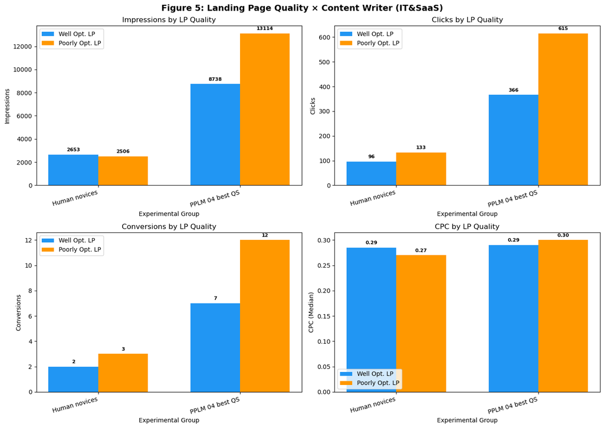

```python
# =============================================
# Figure 5 — Grouped Bar Chart Visualisation
# =============================================
# Four panels (2 × 2): Impressions, Clicks, Conversions, CPC (Median).
# Blue = well-optimised LP, Orange = poorly-optimised LP.
# Each bar is annotated with its numeric value.

def add_bar_labels(ax, bars, fmt='{:.0f}'):
    """Add a text label above each bar showing its value."""
    for bar in bars:
        height = bar.get_height()
        ax.annotate(fmt.format(height),
                    xy=(bar.get_x() + bar.get_width() / 2, height),
                    xytext=(0, 4),            # 4 pt offset above the bar
                    textcoords='offset points',
                    ha='center', va='bottom',
                    fontsize=8, fontweight='bold')

fig, axes = plt.subplots(2, 2, figsize=(14, 10))

groups = comparison_impr['Group'].values
x = np.arange(len(groups))
width = 0.35

# --- Panel 1: Impressions ---
bars1a = axes[0, 0].bar(x - width/2, comparison_impr['Well Opt. LP'], width,
                        label='Well Opt. LP', color='#2196F3')
bars1b = axes[0, 0].bar(x + width/2, comparison_impr['Poorly Opt. LP'], width,
                        label='Poorly Opt. LP', color='#FF9800')
add_bar_labels(axes[0, 0], bars1a)
add_bar_labels(axes[0, 0], bars1b)
axes[0, 0].set_xlabel('Experimental Group')
axes[0, 0].set_ylabel('Impressions')
axes[0, 0].set_title('Impressions by LP Quality')
axes[0, 0].set_xticks(x)
axes[0, 0].set_xticklabels(groups, rotation=15, ha='right')
axes[0, 0].legend()

# --- Panel 2: Clicks ---
bars2a = axes[0, 1].bar(x - width/2, comparison_clicks['Well Opt. LP'], width,
                        label='Well Opt. LP', color='#2196F3')
bars2b = axes[0, 1].bar(x + width/2, comparison_clicks['Poorly Opt. LP'], width,
                        label='Poorly Opt. LP', color='#FF9800')
add_bar_labels(axes[0, 1], bars2a)
add_bar_labels(axes[0, 1], bars2b)
axes[0, 1].set_xlabel('Experimental Group')
axes[0, 1].set_ylabel('Clicks')
axes[0, 1].set_title('Clicks by LP Quality')
axes[0, 1].set_xticks(x)
axes[0, 1].set_xticklabels(groups, rotation=15, ha='right')
axes[0, 1].legend()

# --- Panel 3: Conversions (estimated) ---
bars3a = axes[1, 0].bar(x - width/2, comparison_conv['Well Opt. LP'], width,
                        label='Well Opt. LP', color='#2196F3')
bars3b = axes[1, 0].bar(x + width/2, comparison_conv['Poorly Opt. LP'], width,
                        label='Poorly Opt. LP', color='#FF9800')
add_bar_labels(axes[1, 0], bars3a)
add_bar_labels(axes[1, 0], bars3b)
axes[1, 0].set_xlabel('Experimental Group')
axes[1, 0].set_ylabel('Conversions')
axes[1, 0].set_title('Conversions by LP Quality')
axes[1, 0].set_xticks(x)
axes[1, 0].set_xticklabels(groups, rotation=15, ha='right')
axes[1, 0].legend()

# --- Panel 4: CPC (Median) — use 2 decimal places ---
bars4a = axes[1, 1].bar(x - width/2, comparison_cpc['Well Opt. LP'], width,
                        label='Well Opt. LP', color='#2196F3')
bars4b = axes[1, 1].bar(x + width/2, comparison_cpc['Poorly Opt. LP'], width,
                        label='Poorly Opt. LP', color='#FF9800')
add_bar_labels(axes[1, 1], bars4a, fmt='{:.2f}')
add_bar_labels(axes[1, 1], bars4b, fmt='{:.2f}')
axes[1, 1].set_xlabel('Experimental Group')
axes[1, 1].set_ylabel('CPC (Median)')
axes[1, 1].set_title('CPC by LP Quality')
axes[1, 1].set_xticks(x)
axes[1, 1].set_xticklabels(groups, rotation=15, ha='right')
axes[1, 1].legend()

plt.suptitle('Figure 5: Landing Page Quality × Content Writer (IT&SaaS)', fontsize=14, fontweight='bold')
plt.tight_layout()
plt.show()
```

## Figure 6: SEA Performance Under Varying Budgetary Restrictions — IT&SaaS

Replicates **Figure 6** from the paper.  
Compares **high budget** (from Table 3 IT data) vs. **low budget** conditions.  
Metrics: Impressions, Clicks, Conversions, CPC.  
Tests: Chi-squared, Proportion tests, Kruskal-Wallis.

```python
# =============================================
# Figure 6 — IT&SaaS: Load Data
# =============================================
# fig6 contains the *low-budget* condition.
# The *high-budget* condition reuses IT_tab3 (already loaded in Table 3).
rdata_f6 = load_rdata("Figure 6 IT.RData")
print("Objects loaded:", list(rdata_f6.keys()))

fig6 = rdata_f6['fig6']
print("\n--- fig6 (low budget) columns ---")
print(fig6.columns.tolist())
print(f"Shape: {fig6.shape}")
print("\nNote: IT_tab3 (high budget) was loaded earlier in the Table 3 section.")
```

```
Objects loaded: ['fig6']

--- fig6 (low budget) columns ---
['Anzeigentitel.1', 'Anzeigentitel.2', 'Anzeigentitel.3', 'Textzeile.1', 'Textzeile.2', 'Impr.', 'Interaktionen', 'Interaktionsrate', 'Durchschn..Kosten', 'Kosten', 'CTR', 'Klicks', 'Durchschn..CPC', 'Impr...oberste.Pos...', 'Impr...obere.Pos...', 'Experimental.group']
Shape: (162, 16)

Note: IT_tab3 (high budget) was loaded earlier in the Table 3 section.
```

```python
# =============================================
# Figure 6 — High Budget vs Low Budget: Full Analysis
# =============================================
# For each KPI we report:
#   a) Within-budget chi-squared (do groups differ?)
#   b) Cross-budget chi-squared contingency test (does budget level matter?)

# ---- IMPRESSIONS ----
print("=" * 60)
print("  IMPRESSIONS")
print("=" * 60)

# High budget (from Table 3 IT)
No_impr_high = IT_tab3.groupby('Experimental.group')['Impr.'].sum().reset_index()
No_impr_high.columns = ['Category', 'Impressions']
print("\nHigh Budget:")
display(No_impr_high)
chi2_high = stats.chisquare(No_impr_high['Impressions'])
print(f"  Chi-squared: statistic={chi2_high.statistic:.4f}, p-value={chi2_high.pvalue:.4f}")

# Low budget (from Figure 6 data)
No_impr_low = fig6.groupby('Experimental.group')['Impr.'].sum().reset_index()
No_impr_low.columns = ['Category', 'Impressions']
print("\nLow Budget:")
display(No_impr_low)
chi2_low = stats.chisquare(No_impr_low['Impressions'])
print(f"  Chi-squared: statistic={chi2_low.statistic:.4f}, p-value={chi2_low.pvalue:.4f}")

# Cross-budget contingency-table test
impr_test = pd.DataFrame({
    'High': No_impr_high['Impressions'].values,
    'Low': No_impr_low['Impressions'].values
})
chi2_cross = stats.chi2_contingency(impr_test.values)
print(f"\n  Cross-budget chi-squared: statistic={chi2_cross[0]:.4f}, p-value={chi2_cross[1]:.4f}")

# ---- CLICKS ----
print("\n" + "=" * 60)
print("  CLICKS")
print("=" * 60)

No_clicks_high = IT_tab3.groupby('Experimental.group')['Klicks'].sum().reset_index()
No_clicks_high.columns = ['Category', 'Clicks']
print("\nHigh Budget:")
display(No_clicks_high)
chi2_high = stats.chisquare(No_clicks_high['Clicks'])
print(f"  Chi-squared: statistic={chi2_high.statistic:.4f}, p-value={chi2_high.pvalue:.4f}")

No_clicks_low = fig6.groupby('Experimental.group')['Klicks'].sum().reset_index()
No_clicks_low.columns = ['Category', 'Clicks']
print("\nLow Budget:")
display(No_clicks_low)
chi2_low = stats.chisquare(No_clicks_low['Clicks'])
print(f"  Chi-squared: statistic={chi2_low.statistic:.4f}, p-value={chi2_low.pvalue:.4f}")

clicks_test = pd.DataFrame({
    'High': No_clicks_high['Clicks'].values,
    'Low': No_clicks_low['Clicks'].values
})
chi2_cross = stats.chi2_contingency(clicks_test.values)
print(f"\n  Cross-budget chi-squared: statistic={chi2_cross[0]:.4f}, p-value={chi2_cross[1]:.4f}")

# ---- CONVERSIONS ----
print("\n" + "=" * 60)
print("  CONVERSIONS")
print("=" * 60)

# Estimated conversions using group-specific rates (Table A19 Web Appendix)
conv_rates = [0.0197, 0.02, 0.02]
No_Conv_high = np.round(No_clicks_high['Clicks'].values * conv_rates).astype(int)
No_Conv_low  = np.round(No_clicks_low['Clicks'].values  * conv_rates).astype(int)

conv_df = pd.DataFrame({
    'Group': No_clicks_high['Category'],
    'High Budget': No_Conv_high,
    'Low Budget': No_Conv_low
})
display(conv_df)

chi2_conv_h = stats.chisquare(No_Conv_high)
print(f"High budget conversions chi-sq: statistic={chi2_conv_h.statistic:.4f}, p-value={chi2_conv_h.pvalue:.4f}")
chi2_conv_l = stats.chisquare(No_Conv_low)
print(f"Low budget conversions chi-sq: statistic={chi2_conv_l.statistic:.4f}, p-value={chi2_conv_l.pvalue:.4f}")

# Cross-budget contingency test for conversions
# Note: zero cells may occur → fall back to Fisher's exact test
conv_test = np.column_stack([No_Conv_high, No_Conv_low])
print("Conversions contingency table:")
print(conv_test)
try:
    chi2_cross_conv = stats.chi2_contingency(conv_test)
    print(f"Cross-budget chi-squared: statistic={chi2_cross_conv[0]:.4f}, p-value={chi2_cross_conv[1]:.4f}")
except ValueError as e:
    print(f"  chi2_contingency not applicable (zero cell): {e}")
    if conv_test.shape == (2, 2):
        fisher_result = stats.fisher_exact(conv_test)
        print(f"  Fisher's exact test: odds_ratio={fisher_result[0]:.4f}, p-value={fisher_result[1]:.4f}")
    else:
        print("  Note: Table contains zero cells; chi-squared approximation may be unreliable.")

# Proportion z-test (replicates R's prop.test(x=c(30,10), n=c(39,12)))
z_stat, p_val = proportions_ztest([30, 10], [39, 12], alternative='two-sided')
print(f"Proportion test (willingness to invest): z={z_stat:.4f}, p-value={p_val:.4f}")

# ---- CPC ----
print("\n" + "=" * 60)
print("  CPC")
print("=" * 60)

# High budget CPC descriptives + Kruskal-Wallis
CPC_high = IT_tab3.groupby('Experimental.group')['Durchschn..CPC'].agg(
    Median='median', IQR=lambda x: stats.iqr(x, nan_policy='omit'),
    Min='min', Max='max'
).reset_index()
CPC_high.columns = ['Category', 'Median', 'IQR', 'Min', 'Max']
print("\nHigh Budget CPC:")
display(CPC_high)
groups_cpc_h = [g['Durchschn..CPC'].dropna().values for _, g in IT_tab3.groupby('Experimental.group')]
kw_h = stats.kruskal(*groups_cpc_h)
print(f"  Kruskal-Wallis: statistic={kw_h.statistic:.4f}, p-value={kw_h.pvalue:.4f}")

# Low budget CPC descriptives + Kruskal-Wallis
CPC_low = fig6.groupby('Experimental.group')['Durchschn..CPC'].agg(
    Median='median', IQR=lambda x: stats.iqr(x, nan_policy='omit'),
    Min='min', Max='max'
).reset_index()
CPC_low.columns = ['Category', 'Median', 'IQR', 'Min', 'Max']
print("\nLow Budget CPC:")
display(CPC_low)
groups_cpc_l = [g['Durchschn..CPC'].dropna().values for _, g in fig6.groupby('Experimental.group')]
kw_l = stats.kruskal(*groups_cpc_l)
print(f"  Kruskal-Wallis: statistic={kw_l.statistic:.4f}, p-value={kw_l.pvalue:.4f}")

# Grand Kruskal-Wallis across all 6 cells (3 groups × 2 budget levels)
fig6_copy = fig6.copy()
fig6_copy['grandgr'] = 'low budget ' + fig6_copy['Experimental.group'].astype(str)
IT_tab3_copy = IT_tab3.copy()
IT_tab3_copy['grandgr'] = 'high budget ' + IT_tab3_copy['Experimental.group'].astype(str)
testdat = pd.concat([fig6_copy, IT_tab3_copy])
groups_grand = [g['Durchschn..CPC'].dropna().values for _, g in testdat.groupby('grandgr')]
kw_grand = stats.kruskal(*groups_grand)
print(f"\nGrand Kruskal-Wallis (all budget × group): statistic={kw_grand.statistic:.4f}, p-value={kw_grand.pvalue:.4f}")
```

```
============================================================
  IMPRESSIONS
============================================================

High Budget:
```

|  | Category | Impressions |
| --- | --- | --- |
| 0 | Human novices | 12031.0 |
| 1 | PPLM 04 best QS | 34590.0 |
| 2 | Real experts | 1255.0 |

```
  Chi-squared: statistic=36265.6212, p-value=0.0000

Low Budget:
```

|  | Category | Impressions |
| --- | --- | --- |
| 0 | Human novices | 4866.0 |
| 1 | PPLM 04 best QS | 11257.0 |
| 2 | Real experts | 364.0 |

```
  Chi-squared: statistic=10903.7626, p-value=0.0000

  Cross-budget chi-squared: statistic=125.2979, p-value=0.0000

============================================================
  CLICKS
============================================================

High Budget:
```

|  | Category | Clicks |
| --- | --- | --- |
| 0 | Human novices | 530.0 |
| 1 | PPLM 04 best QS | 1507.0 |
| 2 | Real experts | 7.0 |

```
  Chi-squared: statistic=1701.5939, p-value=0.0000

Low Budget:
```

|  | Category | Clicks |
| --- | --- | --- |
| 0 | Human novices | 121.0 |
| 1 | PPLM 04 best QS | 439.0 |
| 2 | Real experts | 5.0 |

```
  Chi-squared: statistic=536.1699, p-value=0.0000

  Cross-budget chi-squared: statistic=7.3822, p-value=0.0249

============================================================
  CONVERSIONS
============================================================
```

|  | Group | High Budget | Low Budget |
| --- | --- | --- | --- |
| 0 | Human novices | 10 | 2 |
| 1 | PPLM 04 best QS | 30 | 9 |
| 2 | Real experts | 0 | 0 |

```
High budget conversions chi-sq: statistic=35.0000, p-value=0.0000
Low budget conversions chi-sq: statistic=12.1818, p-value=0.0023
Conversions contingency table:
[[10  2]
 [30  9]
 [ 0  0]]
  chi2_contingency not applicable (zero cell): The internally computed table of expected frequencies has a zero element at (2, 0).
  Note: Table contains zero cells; chi-squared approximation may be unreliable.
Proportion test (willingness to invest): z=-0.4721, p-value=0.6368

============================================================
  CPC
============================================================

High Budget CPC:
```

|  | Category | Median | IQR | Min | Max |
| --- | --- | --- | --- | --- | --- |
| 0 | Human novices | 0.260 | 0.075 | 0.06 | 3.28 |
| 1 | PPLM 04 best QS | 0.285 | 0.080 | 0.03 | 4.52 |
| 2 | Real experts | 0.380 | 0.000 | 0.38 | 0.38 |

```
  Kruskal-Wallis: statistic=7.0875, p-value=0.0289

Low Budget CPC:
```

|  | Category | Median | IQR | Min | Max |
| --- | --- | --- | --- | --- | --- |
| 0 | Human novices | 0.150 | 0.0400 | 0.07 | 0.20 |
| 1 | PPLM 04 best QS | 0.150 | 0.0200 | 0.05 | 0.23 |
| 2 | Real experts | 0.095 | 0.0275 | 0.08 | 0.16 |

```
  Kruskal-Wallis: statistic=3.6863, p-value=0.1583

Grand Kruskal-Wallis (all budget × group): statistic=98.2581, p-value=0.0000
```

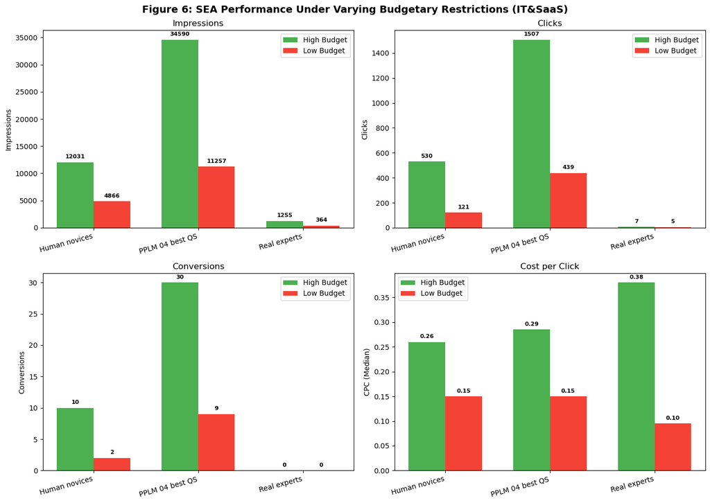

```python
# =============================================
# Figure 6 — 2 × 2 Bar Chart Visualisation
# =============================================
# Four panels: Impressions, Clicks, Conversions, CPC.
# Green = high budget, Red = low budget.
# Each bar is annotated with its numeric value.

fig, axes = plt.subplots(2, 2, figsize=(14, 10))

groups = No_impr_high['Category'].values
x = np.arange(len(groups))
width = 0.35

# --- Panel 1: Impressions ---
bars1a = axes[0, 0].bar(x - width/2, No_impr_high['Impressions'], width, label='High Budget', color='#4CAF50')
bars1b = axes[0, 0].bar(x + width/2, No_impr_low['Impressions'], width, label='Low Budget', color='#F44336')
add_bar_labels(axes[0, 0], bars1a)
add_bar_labels(axes[0, 0], bars1b)
axes[0, 0].set_ylabel('Impressions')
axes[0, 0].set_title('Impressions')
axes[0, 0].set_xticks(x)
axes[0, 0].set_xticklabels(groups, rotation=15, ha='right')
axes[0, 0].legend()

# --- Panel 2: Clicks ---
bars2a = axes[0, 1].bar(x - width/2, No_clicks_high['Clicks'], width, label='High Budget', color='#4CAF50')
bars2b = axes[0, 1].bar(x + width/2, No_clicks_low['Clicks'], width, label='Low Budget', color='#F44336')
add_bar_labels(axes[0, 1], bars2a)
add_bar_labels(axes[0, 1], bars2b)
axes[0, 1].set_ylabel('Clicks')
axes[0, 1].set_title('Clicks')
axes[0, 1].set_xticks(x)
axes[0, 1].set_xticklabels(groups, rotation=15, ha='right')
axes[0, 1].legend()

# --- Panel 3: Conversions ---
bars3a = axes[1, 0].bar(x - width/2, No_Conv_high, width, label='High Budget', color='#4CAF50')
bars3b = axes[1, 0].bar(x + width/2, No_Conv_low, width, label='Low Budget', color='#F44336')
add_bar_labels(axes[1, 0], bars3a)
add_bar_labels(axes[1, 0], bars3b)
axes[1, 0].set_ylabel('Conversions')
axes[1, 0].set_title('Conversions')
axes[1, 0].set_xticks(x)
axes[1, 0].set_xticklabels(groups, rotation=15, ha='right')
axes[1, 0].legend()

# --- Panel 4: CPC (Median) — use 2 decimal places ---
bars4a = axes[1, 1].bar(x - width/2, CPC_high['Median'], width, label='High Budget', color='#4CAF50')
bars4b = axes[1, 1].bar(x + width/2, CPC_low['Median'], width, label='Low Budget', color='#F44336')
add_bar_labels(axes[1, 1], bars4a, fmt='{:.2f}')
add_bar_labels(axes[1, 1], bars4b, fmt='{:.2f}')
axes[1, 1].set_ylabel('CPC (Median)')
axes[1, 1].set_title('Cost per Click')
axes[1, 1].set_xticks(x)
axes[1, 1].set_xticklabels(groups, rotation=15, ha='right')
axes[1, 1].legend()

plt.suptitle('Figure 6: SEA Performance Under Varying Budgetary Restrictions (IT&SaaS)',
             fontsize=14, fontweight='bold')
plt.tight_layout()
plt.show()
```